# Lab_Assignment_5

Yifei Ding

2023-11-17

```r
Sys.setenv(LANG = "en")
setwd("E:/R/R program/Data-Analysis-for-Economics-ECON106A-23-FALL/Lab Assignments")
library(tidyverse)
library(sf)
library(units)
```

Part I. Cleanup 1. Read in the District Areas Shapefile. Transform the CRS to CA Albers Equal Area.

```r
School_Districts<-st_read("DistrictAreas2122.shp")
```

2. Read in the District College Outcomes csv file. Convert the CDCode to character. Create a variable that represents the CSU going rate. Create a variable that represents the UC going rate.
3. Left Join the District Areas sf object to the District College outcomes.

```r
#read in college outcomes by district
District_College_Outcomes<-read_csv("District College Outcomes.csv")
District_College_Outcomes<-District_College_Outcomes%>%
  mutate(CDCode=as.character(CDCode))

School_Districts_join<-left_join(x=School_Districts, y=District_College_Outcomes)

#use albers projections
School_Districts_Albers<-st_transform(School_Districts_join, crs=3310)

School_Districts_rates<- School_Districts_Albers %>%
  mutate(CSU_rate=`Enrolled CSU (12 Months)`/`High School Completers`,
         UC_rate = `Enrolled UC (12 Months)`/`High School Completers`)
```

4.Read in the college locations csv file. Convert the data frame to a sf object. Transform the CRS to CA Albers Equal Area. Create a sf object for campuses that are part of the CSU system. Create a sf object for campuses that are part of the UC system

```r
#load excel file of GPS coordinates of college campuses into R
college_data <- read_csv("college locations.csv")

#select CSU's from this dataset
CSU_data <-college_data %>%
  filter(F1SYSNAM == "California State University")

# Convert CSU_data to a sf object
CSU_sf <- st_as_sf(CSU_data, coords = c("LONGITUD", "LATITUDE"), crs = 4269)

#select UC's from this dataset
UC_data <-college_data %>%
  filter(F1SYSNAM == "University of California")%>%
  filter(IALIAS!="UCOP")

# Convert CSU_data to a sf object
UC_sf <- st_as_sf(UC_data, coords = c("LONGITUD", "LATITUDE"), crs = 4269)

CSUSB<-CSU_sf%>%
  filter(IALIAS=="Cal State San Bernardino")
```

```r
#project to CA Albers

UC_Albers<-st_transform(UC_sf, crs=3310)

CSU_Albers<-st_transform(CSU_sf, crs=3310)

CSUSB_Albers<-st_transform(CSUSB, crs=3310)
```

Part II. Analysis 1. Create a map of CSU going rates by district with the CSU locations overlayed.

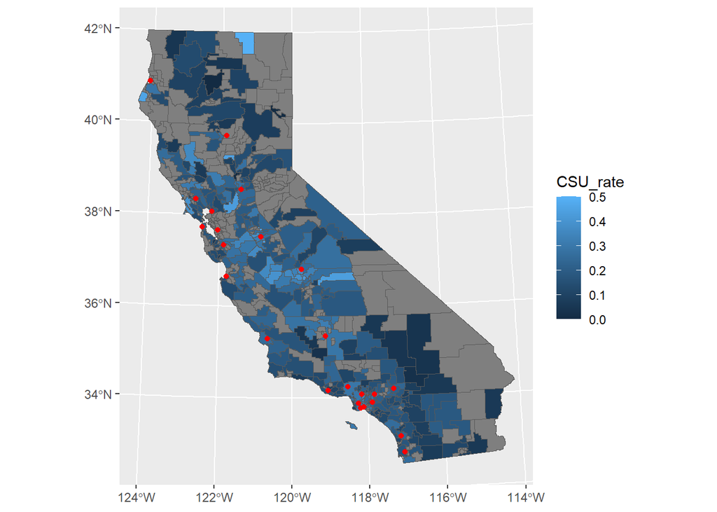

```r
#csu going & CSU locations
ggplot()+
  geom_sf(data=School_Districts_rates, aes(fill=`CSU_rate`))+
  geom_sf(data=CSU_Albers, color='red')
```

2.Create a map of the UC going rates by district with the UC locations overlayed.

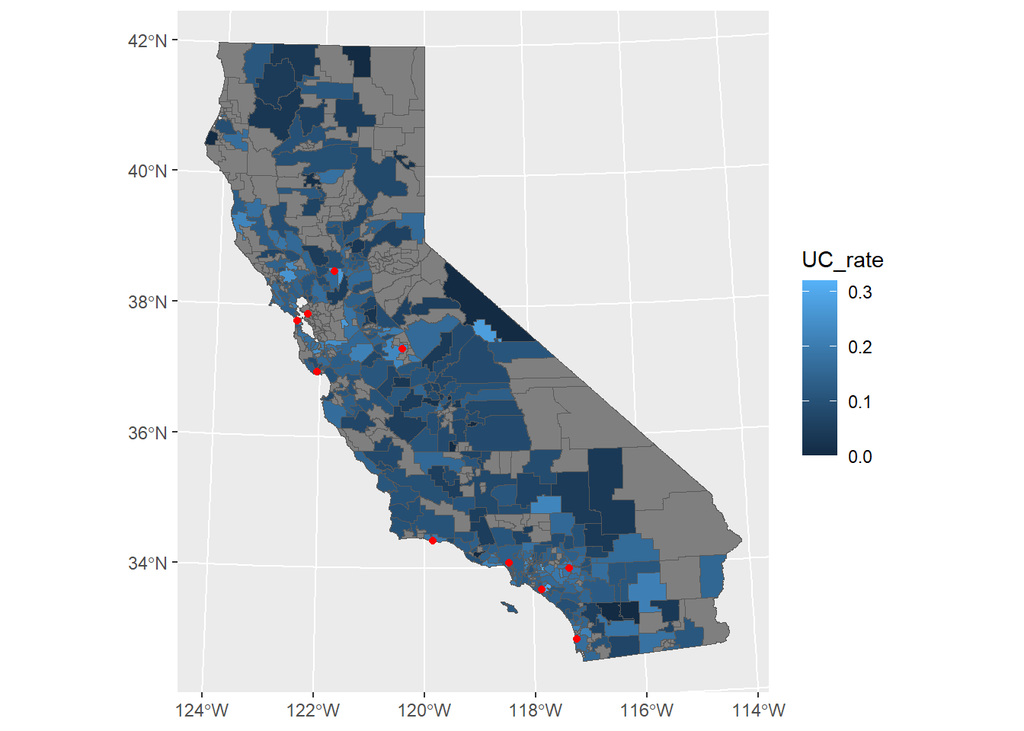

```r
#uc going & uc locations
ggplot()+
  geom_sf(data=School_Districts_rates, aes(fill=`UC_rate`))+
  geom_sf(data=UC_Albers, color='red')
```

4. Let’s focus on school districts in Riverside County. Find the following: a. The largest school district by area (sq miles) b. The largest school district by #enrolled students c. The school district with the highest CSU going rate

```r
Riverside_Districts<-School_Districts_rates%>%
  filter(CountyName=="Riverside")
```

```r
#what is the largest school district in Riverside by Area (square miles)?
Riverside_Districts%>%
  mutate(area=set_units(st_area(Riverside_Districts), mi^2))%>%
arrange(desc(area))%>%
  select(DistrictNa, area)%>%
  slice_head(n=5)
```

```
## Simple feature collection with 5 features and 2 fields
## Geometry type: MULTIPOLYGON
## Dimension:     XY
## Bounding box:  xmin: 265504.2 ymin: -521656.9 xmax: 513583.9 ymax: -422255.7
## Projected CRS: NAD83 / California Albers
##                 DistrictNa             area                       geometry
## 1    Desert Center Unified 1736.0844 [mi^2] MULTIPOLYGON (((467934.7 -4...
## 2 Coachella Valley Unified 1219.9688 [mi^2] MULTIPOLYGON (((400726.4 -4...
## 3       Palo Verde Unified 1063.1019 [mi^2] MULTIPOLYGON (((513266.7 -4...
## 4     Desert Sands Unified  768.9278 [mi^2] MULTIPOLYGON (((399938.8 -4...
## 5            Hemet Unified  646.8199 [mi^2] MULTIPOLYGON (((313785 -470...
```

```r
#what is the largest school district in Riverside by # Total Enrollment?
Riverside_Districts%>%
  arrange(desc(EnrollTota))%>%
  select(DistrictNa, EnrollTota)%>%
  slice_head(n=5)
```

```
## Simple feature collection with 5 features and 2 fields
## Geometry type: MULTIPOLYGON
## Dimension:     XY
## Bounding box:  xmin: 214918.8 ymin: -505385.5 xmax: 400962.4 ymax: -433105.6
## Projected CRS: NAD83 / California Albers
##                DistrictNa EnrollTota                       geometry
## 1    Corona-Norco Unified      50889 MULTIPOLYGON (((228898.3 -4...
## 2       Riverside Unified      40247 MULTIPOLYGON (((251288.5 -4...
## 3   Moreno Valley Unified      31609 MULTIPOLYGON (((261064.4 -4...
## 4 Temecula Valley Unified      28165 MULTIPOLYGON (((284142.7 -5...
## 5    Desert Sands Unified      26698 MULTIPOLYGON (((399938.8 -4...
```

```r
#what is the school district with the highest CSU college going rates?
Riverside_Districts%>%
  arrange(desc(CSU_rate))%>%
  select(DistrictNa, CSU_rate)%>%
  slice_head(n=5)
```

```
## Simple feature collection with 5 features and 2 fields
## Geometry type: MULTIPOLYGON
## Dimension:     XY
## Bounding box:  xmin: 225448.6 ymin: -521656.9 xmax: 411973.5 ymax: -435893.1
## Projected CRS: NAD83 / California Albers
##                 DistrictNa  CSU_rate                       geometry
## 1           Jurupa Unified 0.2047930 MULTIPOLYGON (((243044.3 -4...
## 2        Perris Union High 0.1958495 MULTIPOLYGON (((266391.8 -4...
## 3 Coachella Valley Unified 0.1860465 MULTIPOLYGON (((400726.4 -4...
## 4             Nuview Union 0.1851852 MULTIPOLYGON (((273140.4 -4...
## 5     Palm Springs Unified 0.1797603 MULTIPOLYGON (((341521.1 -4...
```

5. Calculate the distance between the Riverside School District Centroids and CSU San Bernadino (the closest CSU). Is the school district with the highest CSU going rate the closest to CSUSB?

```r
Jurupa_Unified<-Riverside_Districts%>%
  filter(DistrictNa=="Jurupa Unified")

set_units(st_distance(Jurupa_Unified, CSUSB_Albers), mi)
```

```
## Units: [mi]
##          [,1]
## [1,] 10.66952
```

```r
Riverside_Districts_Centroids <- st_centroid(Riverside_Districts)
Distance_RDC_CSUSB <- set_units( st_distance(CSUSB_Albers, Riverside_Districts_Centroids) , mi)
colnames(Distance_RDC_CSUSB) <- Riverside_Districts_Centroids$DistrictNa
Distance_RDC_CSUSB
```

```
## Units: [mi]
##      Alvord Unified Banning Unified Beaumont Unified Corona-Norco Unified
## [1,]       21.43692        37.27247         23.97022             26.27646
##      Desert Center Unified Desert Sands Unified Hemet Unified Jurupa Unified
## [1,]              121.1603             73.75451      50.41818       14.97392
##      Menifee Union Elementary Moreno Valley Unified Nuview Union
## [1,]                 36.65004              18.28486     28.11795
##      Palm Springs Unified Palo Verde Unified Perris Elementary
## [1,]             55.52884           151.8639          28.35767
##      Perris Union High Riverside Unified Romoland Elementary
## [1,]          31.27148          17.91679              31.669
##      San Jacinto Unified Coachella Valley Unified Lake Elsinore Unified
## [1,]            30.02115                 91.44416              35.18541
##      Temecula Valley Unified Murrieta Valley Unified Val Verde Unified
## [1,]                47.84821                44.84693          23.70827
```